# Visualize nationality predictions

```r
all_full_names <- read_tsv('data/names/full-names.tsv.xz') %>% distinct()
nationalize_df <- read_tsv('https://raw.githubusercontent.com/greenelab/wiki-nationality-estimate/a92a37284ef5a097c3f499fef782fd20f40e050c/data/LSTM_results_authors.tsv') %>%
  rename('full_name' = X1) %>%
  distinct(full_name, .keep_all = T) %>%
  left_join(all_full_names, by = 'full_name')
alpha_threshold <- qnorm(0.975)

pubmed_nat_pmids <- read_tsv('data/names/corresponding-authors.tsv.xz') %>%
  left_join(read_tsv('data/pubmed/articles.tsv.xz'), by = 'pmid') %>%
  mutate(year = substr(publication_date, 1, 4) %>% ymd(truncated = 2),
         publication_date = ymd(publication_date, truncated = 2)) %>%
  left_join(nationalize_df, by = c('fore_name', 'last_name'))
pubmed_nat_df <- pubmed_nat_pmids %>%
  group_by(pmid, journal, publication_date, year) %>%
  summarise_at(vars(African:SouthAsian), mean, na.rm = T) %>%
  ungroup()

iscb_nat_df <- read_tsv('data/iscb/keynotes.tsv') %>%
  mutate(publication_date = ymd(year, truncated = 2),
         year = ymd(year, truncated = 2)) %>%
  left_join(nationalize_df, by = c('fore_name', 'last_name')) %>%
  filter(conference != 'PSB') # remove PSB
start_year <- 1997
end_year <- 2019
n_years <- end_year - start_year
my_jours <- unique(pubmed_nat_df$journal)
my_confs <- unique(iscb_nat_df$conference)
n_jours <- length(my_jours)
n_confs <- length(my_confs)
region_levels <- c('Celtic English', 'European', 'East Asian', 'Hispanic', 'South Asian', 'Muslim', 'Israeli', 'African')
region_levels_let <- toupper(letters[1:8])
```

```r
set.seed(0)
top_names <- map_dfc(colnames(nationalize_df)[-1], function(x) {
  nationalize_df %>%
    filter((!!sym(x)) > 0.9) %>%
    sample_n(10) %>%
    select(full_name) %>%
    rename(!!x := full_name)
  })

top_names %>% write_tsv('data/names/example_nationalities.tsv')
```

## Missing data

```r
iscb_nat_df %>% filter(is.na(African))
```

```
## # A tibble: 22 x 20
##    year       full_name.x fore_name last_name conference source
##    <date>     <chr>       <chr>     <chr>     <chr>      <chr>
##  1 1993-01-01 Harold Mor… Harold    Morowitz  ISMB       https…
##  2 1994-01-01 Bruce Buch… Bruce     Buchanan  ISMB       https…
##  3 1995-01-01 John Sulton John      Sulton    ISMB       https…
##  4 1995-01-01 Doug Brutl… Doug      Brutlag   ISMB       https…
##  5 1996-01-01 Robert Wat… Robert    Waterston ISMB       https…
##  6 1997-01-01 Fotis C. K… Fotis     Kafatos   ISMB       https…
##  7 1997-01-01 Marcie McC… Marcie    McClure   ISMB       https…
##  8 1997-01-01 Hans V. We… Hans      Westerho… ISMB       https…
##  9 1998-01-01 Robert Ced… Robert    Cedergren ISMB       https…
## 10 1999-01-01 Manfred Ei… Manfred   Eigen     ISMB       https…
## # … with 12 more rows, and 14 more variables: affiliations <chr>,
## #   afflcountries <chr>, publication_date <date>, full_name.y <chr>,
## #   African <dbl>, CelticEnglish <dbl>, EastAsian <dbl>, European <dbl>,
## #   Hispanic <dbl>, Israel <dbl>, Muslim <dbl>, SouthAsian <dbl>,
## #   fore_name_simple <chr>, last_name_simple <chr>
```

```r
pubmed_nat_pmids %>% filter(is.na(African))
```

```
## # A tibble: 1,506 x 30
##      pmid pmcid.x position fore_name last_name corresponding
##     <dbl> <chr>      <dbl> <chr>     <chr>             <dbl>
##  1 1.28e7 PMC161…        1 HJ        Purohit               1
##  2 1.51e7 PMC394…        6 N         Srinivas…             1
##  3 1.52e7 PMC446…        1 DA        Pollard               1
##  4 1.52e7 PMC446…        2 CM        Bergman               1
##  5 1.54e7 PMC520…        3 J-J       Daudin                1
##  6 1.58e7 PMC127…        2 RW        Doerge                1
##  7 1.58e7 PMC127…        6 J         Snoddy                1
##  8 1.58e7 PMC109…        1 AM        Cohen                 1
##  9 1.59e7 PMC113…        4 KV        Venkatesh             1
## 10 1.59e7 PMC109…        6 M         Caselle               1
## # … with 1,496 more rows, and 24 more variables: reverse_position <dbl>,
## #   countries <chr>, source <chr>, use_last <dbl>, n_corresponding <dbl>,
## #   fore_name_simple.x <chr>, last_name_simple.x <chr>, pmcid.y <chr>,
## #   doi <chr>, journal <chr>, publication_date <date>, title <chr>,
## #   year <date>, full_name <chr>, African <dbl>, CelticEnglish <dbl>,
## #   EastAsian <dbl>, European <dbl>, Hispanic <dbl>, Israel <dbl>,
## #   Muslim <dbl>, SouthAsian <dbl>, fore_name_simple.y <chr>,
## #   last_name_simple.y <chr>
```

```r
pubmed_nat_pmids %>% filter(is.na(African)&!is.na(fore_name_simple.x))
```

```
## # A tibble: 0 x 30
## # … with 30 variables: pmid <dbl>, pmcid.x <chr>, position <dbl>,
## #   fore_name <chr>, last_name <chr>, corresponding <dbl>,
## #   reverse_position <dbl>, countries <chr>, source <chr>, use_last <dbl>,
## #   n_corresponding <dbl>, fore_name_simple.x <chr>,
## #   last_name_simple.x <chr>, pmcid.y <chr>, doi <chr>, journal <chr>,
## #   publication_date <date>, title <chr>, year <date>, full_name <chr>,
## #   African <dbl>, CelticEnglish <dbl>, EastAsian <dbl>, European <dbl>,
## #   Hispanic <dbl>, Israel <dbl>, Muslim <dbl>, SouthAsian <dbl>,
## #   fore_name_simple.y <chr>, last_name_simple.y <chr>
```

```r
sum(is.na(pubmed_nat_df$African))
```

```
## [1] 1466
```

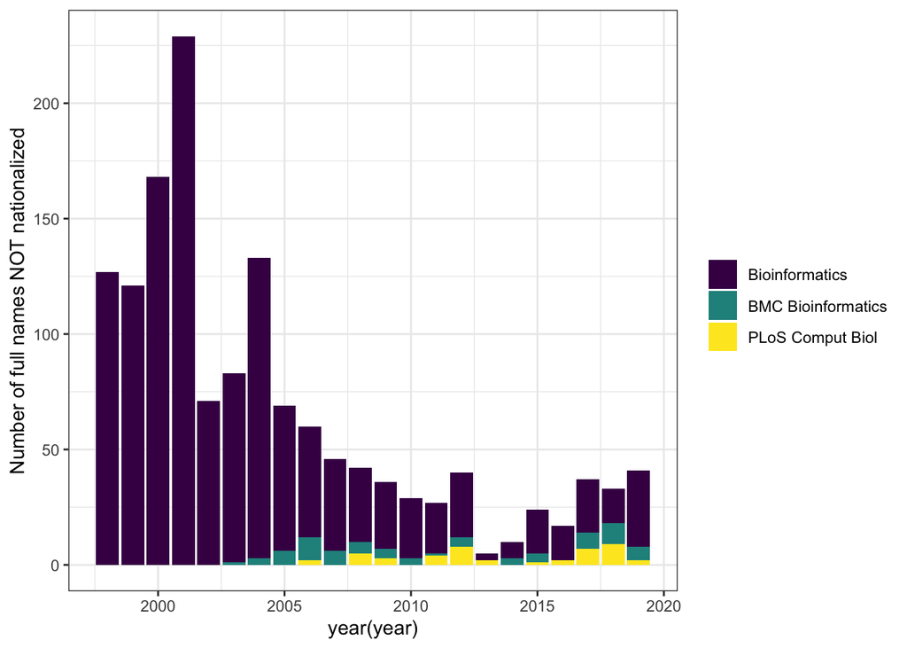

```r
pubmed_nat_df %>% filter(is.na(African)) %>%
  count(year, journal) %>%
  ggplot(aes(year(year), n, fill = journal)) +
  geom_bar(stat = 'identity') +
  scale_fill_viridis_d() +
  ylab('Number of full names NOT nationalized')
```

```r
pubmed_nat_df %>%
  filter(year == '2002-01-01', !is.na(African))
```

```
## # A tibble: 315 x 12
##      pmid journal publication_date year       African CelticEnglish
##     <dbl> <chr>   <date>           <date>       <dbl>         <dbl>
##  1 1.18e7 BMC Bi… 2002-01-10       2002-01-01 1.19e-6      0.000464
##  2 1.18e7 BMC Bi… 2002-01-22       2002-01-01 1.61e-2      0.00230
##  3 1.18e7 Bioinf… 2002-01-01       2002-01-01 9.98e-4      0.957
##  4 1.18e7 Bioinf… 2002-01-01       2002-01-01 6.50e-4      0.0999
##  5 1.18e7 Bioinf… 2002-01-01       2002-01-01 3.38e-1      0.136
##  6 1.18e7 Bioinf… 2002-01-01       2002-01-01 1.24e-5      0.00475
##  7 1.18e7 Bioinf… 2002-01-01       2002-01-01 1.87e-3      0.647
##  8 1.18e7 Bioinf… 2002-01-01       2002-01-01 2.26e-3      0.941
##  9 1.18e7 Bioinf… 2002-01-01       2002-01-01 1.75e-3      0.0167
## 10 1.18e7 Bioinf… 2002-01-01       2002-01-01 4.23e-4      0.0316
## # … with 305 more rows, and 6 more variables: EastAsian <dbl>,
## #   European <dbl>, Hispanic <dbl>, Israel <dbl>, Muslim <dbl>,
## #   SouthAsian <dbl>
```

In 2000, there is only one article that has nationality prediction. (9 articles in 2001). Should we drop?

## Descriptive statistics

Prepare data frames for later analyses:

- rbind results of race predictions in iscb and Pubmed
- pivot long
- compute mean, sd, marginal error

```r
iscb_pubmed_oth <- iscb_nat_df %>%
  rename('journal' = conference) %>%
  select(year, journal, African:SouthAsian, publication_date) %>%
  mutate(type = 'Keynote speakers/Fellows') %>%
  bind_rows(
    pubmed_nat_df %>%
      select(year, journal, African:SouthAsian, publication_date) %>%
      mutate(type = 'Pubmed authors')
  ) %>%
  mutate(OtherCategories = SouthAsian + Hispanic + Muslim + Israel + African) %>%
  pivot_longer(c(African:SouthAsian, OtherCategories),
               names_to = 'region',
               values_to = 'probabilities') %>%
  group_by(type, year, publication_date, region) %>%
  add_count() %>%
  mutate(
    mean_prob = mean(probabilities, na.rm = T),
    sd_prob = sd(probabilities, na.rm = T),
    n = mean(n),
    me_prob = alpha_threshold * sd_prob / sqrt(n)
  ) %>%
  ungroup()

iscb_pubmed <- iscb_pubmed_oth %>%
  filter(region != 'OtherCategories')
```

## Prepare data frames for analysis

### By journals

```r
pubmed_nat <- vector('list', length = n_jours)
i <- 0

for (jour in my_jours){
  i <- i + 1
  pubmed_nat[[i]] <- iscb_pubmed %>%
    filter(type == 'Pubmed authors' & journal == jour) %>%
    group_by(year, region, journal) %>%
    summarise(mean_prob = mean(probabilities, na.rm = T)) %>%
    ungroup()
}
```

### By conference keynotes/fellows

```r
i <- 0
iscb_nat <- vector('list', length = n_confs)

for (conf in my_confs){
  i <- i + 1
  iscb_nat[[i]] <- iscb_pubmed %>%
    filter(type != 'Pubmed authors' & journal == conf) %>%
    group_by(year, region, journal) %>%
    summarise(mean_prob = mean(probabilities, na.rm = T)) %>%
    ungroup()
}
```

```r
iscb_pubmed %>%
    filter(type != 'Pubmed authors' & year == '2011-01-01' & journal == 'PSB')
```

```
## # A tibble: 0 x 10
## # … with 10 variables: year <date>, journal <chr>,
## #   publication_date <date>, type <chr>, region <chr>,
## #   probabilities <dbl>, n <dbl>, mean_prob <dbl>, sd_prob <dbl>,
## #   me_prob <dbl>
```

```r
iscb_nat_df %>% filter(year == '2011-01-01' & conference == 'PSB')
```

```
## # A tibble: 0 x 20
## # … with 20 variables: year <date>, full_name.x <chr>, fore_name <chr>,
## #   last_name <chr>, conference <chr>, source <chr>, affiliations <chr>,
## #   afflcountries <chr>, publication_date <date>, full_name.y <chr>,
## #   African <dbl>, CelticEnglish <dbl>, EastAsian <dbl>, European <dbl>,
## #   Hispanic <dbl>, Israel <dbl>, Muslim <dbl>, SouthAsian <dbl>,
## #   fore_name_simple <chr>, last_name_simple <chr>
```

```r
iscb_nat_df %>% filter(year == '2020-01-01' & conference == 'PSB')
```

```
## # A tibble: 0 x 20
## # … with 20 variables: year <date>, full_name.x <chr>, fore_name <chr>,
## #   last_name <chr>, conference <chr>, source <chr>, affiliations <chr>,
## #   afflcountries <chr>, publication_date <date>, full_name.y <chr>,
## #   African <dbl>, CelticEnglish <dbl>, EastAsian <dbl>, European <dbl>,
## #   Hispanic <dbl>, Israel <dbl>, Muslim <dbl>, SouthAsian <dbl>,
## #   fore_name_simple <chr>, last_name_simple <chr>
```

## Figures for paper

### Figure 4: Compared to the name collection of Pubmed authors, Celtic English honorees are overrepresented while East Asian honorees are underrepresented.

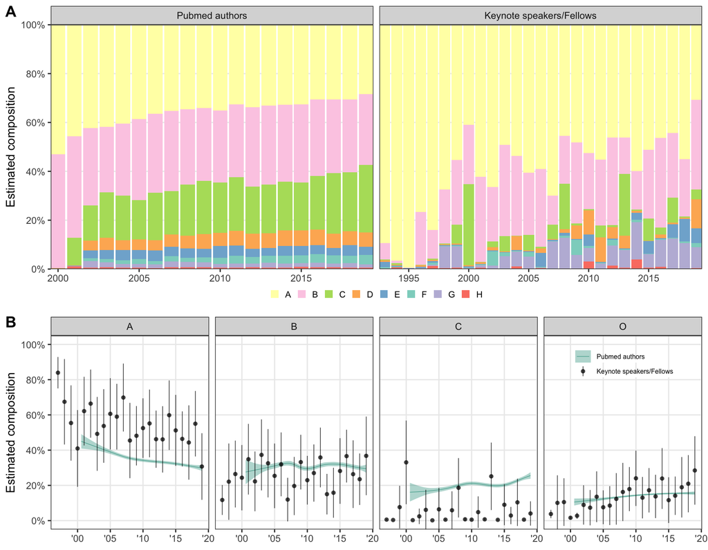

```r
fig_4a <- iscb_pubmed %>%
  filter(year < '2020-01-01') %>%
  group_by(year, type, region) %>%
  summarise(mean_prob = mean(probabilities, na.rm = T)) %>%
  ungroup() %>%
  region_breakdown('main', fct_rev(type)) +
  guides(fill = guide_legend(nrow = 1)) +
  theme(legend.position = 'bottom',
        legend.key.height = unit(3, 'mm'),
        legend.key.width = unit(3, 'mm'),
        legend.text = element_text(size = 8),
        legend.margin = margin(-0.2, 0.2, 0.2, 0, unit='cm'))
## Mean and standard deviation of predicted probabilities:
fig_4b <- iscb_pubmed_oth %>%
  filter(!(region %in% c('Hispanic', 'SouthAsian', 'African', 'Israel', 'Muslim'))) %>%
  recode_region_letter() %>%
  loess_and_ci() +
  theme(legend.position = c(0.88, 0.83),
        legend.key.height = unit(4, 'mm'),
        legend.key.width = unit(5, 'mm'),
        legend.text = element_text(size = 6)) +
  facet_wrap(vars(fct_relevel(region, c('A', 'B', 'C', 'O'))), nrow = 1)
fig_4 <- cowplot::plot_grid(fig_4a, fig_4b, labels = 'AUTO', ncol = 1, rel_heights = c(1.3,1))
fig_4
```

```r
ggsave('figs/region_breakdown.png', fig_4, width = 6.5, height = 5.5)
```

### What about p-values?

```r
w_df <- iscb_pubmed %>% filter(region == 'CelticEnglish', !is.na(probabilities))
w_pub <- w_df %>% filter(type == 'Pubmed authors') %>% pull(probabilities)
w_iscb <- w_df %>% filter(type != 'Pubmed authors') %>% pull(probabilities)

t.test(w_iscb, w_pub, alternative = 'greater') %>%
  broom::tidy() %>%
  select(-contains('estimate')) %>%
  print()
```

```
## # A tibble: 1 x 7
##   statistic  p.value parameter conf.low conf.high method        alternative
##       <dbl>    <dbl>     <dbl>    <dbl>     <dbl> <chr>         <chr>
## 1      9.92 3.51e-21      399.    0.173       Inf Welch Two Sa… greater
```

The Welch two-sample one-sided t-test shows that the mean probability of ISCB speakers predicted to be in group A is higher than that of authors.

```r
w_df <- iscb_pubmed %>% filter(region == 'European', !is.na(probabilities))
w_pub <- w_df %>% filter(type == 'Pubmed authors') %>% pull(probabilities)
w_iscb <- w_df %>% filter(type != 'Pubmed authors') %>% pull(probabilities)

t.test(w_iscb, w_pub) %>%
  broom::tidy() %>%
  select(-contains('estimate')) %>%
  print()
```

```
## # A tibble: 1 x 7
##   statistic p.value parameter conf.low conf.high method         alternative
##       <dbl>   <dbl>     <dbl>    <dbl>     <dbl> <chr>          <chr>
## 1     -2.48  0.0134      402.  -0.0814  -0.00949 Welch Two Sam… two.sided
```

A Welch two-sample t-test also shows a lower mean probability of ISCB speakers predicted to be in group B compared to authors.

```r
w_df <- iscb_pubmed %>% filter(region == 'EastAsian', !is.na(probabilities))
w_pub <- w_df %>% filter(type == 'Pubmed authors') %>% pull(probabilities)
w_iscb <- w_df %>% filter(type != 'Pubmed authors') %>% pull(probabilities)

t.test(w_iscb, w_pub, alternative = 'less') %>%
  broom::tidy() %>%
  select(-contains('estimate')) %>%
  print()
```

```
## # A tibble: 1 x 7
##   statistic  p.value parameter conf.low conf.high method        alternative
##       <dbl>    <dbl>     <dbl>    <dbl>     <dbl> <chr>         <chr>
## 1     -14.0 2.75e-37      424.     -Inf    -0.136 Welch Two Sa… less
```

The Welch two-sample one-sided t-test shows that the mean probability of ISCB speakers predicted to be in group C is lower than that of authors.

```r
w_df <- iscb_pubmed_oth %>% filter(region == 'OtherCategories', !is.na(probabilities))
w_pub <- w_df %>% filter(type == 'Pubmed authors') %>% pull(probabilities)
w_iscb <- w_df %>% filter(type != 'Pubmed authors') %>% pull(probabilities)

t.test(w_iscb, w_pub) %>%
  broom::tidy() %>%
  select(-contains('estimate')) %>%
  print()
```

```
## # A tibble: 1 x 7
##   statistic p.value parameter conf.low conf.high method         alternative
##       <dbl>   <dbl>     <dbl>    <dbl>     <dbl> <chr>          <chr>
## 1    -0.492   0.623      400.  -0.0354    0.0213 Welch Two Sam… two.sided
```

A Welch two-sample t-test does not reveal any difference in mean probability of ISCB speakers predicted to be in other groups compared to authors.

### Supplementary Figure S4

Proportion of authors in the Celtic English categories had decreased, particularly for papers published in Bioinformatics and BMC Bioinformatics. ISMB keynotes had more probability attributable to Israel, while RECOMB had more attributable to East Asian countries

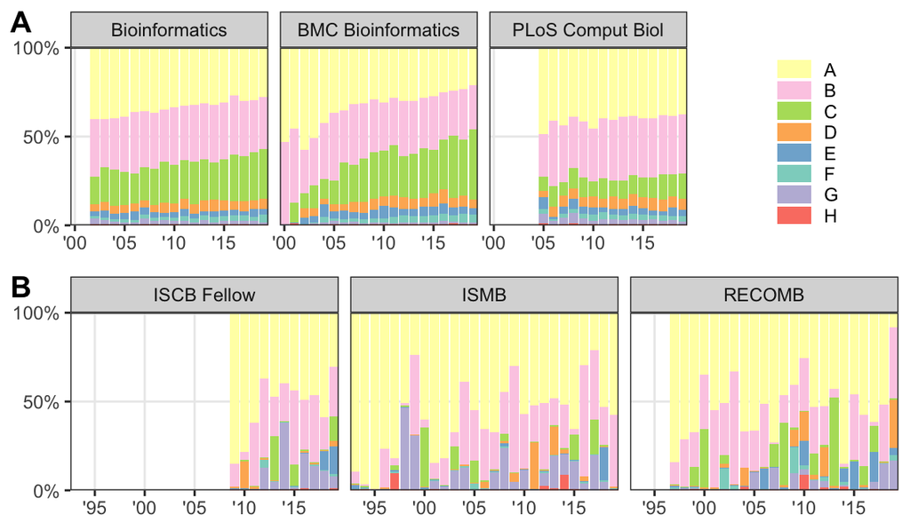

```r
fig_s4_1 <- bind_rows(pubmed_nat) %>%
  region_breakdown(category = 'sub', journal) +
  theme(legend.position = 'right',
        legend.key.height = unit(3.5, 'mm'),
        legend.margin = margin(0, 1, 0, 1.1, unit='cm')
        )
fig_s4_2 <- bind_rows(iscb_nat) %>%
  filter(year < '2020-01-01') %>%
  region_breakdown(category = 'sub', journal)
fig_s4 <- cowplot::plot_grid(fig_s4_1, fig_s4_2, labels = 'AUTO', ncol = 1)
fig_s4
```

```r
ggsave('figs/fig_s4.png', fig_s4, width = 6, height = 3.5)
```

### Supplementary Figure S5

It’s difficult to come to a conclusion for other regions with so few data points and the imperfect accuracy of our prediction. There seems to be little difference between the proportion of keynote speakers of African, Muslim, South Asian and Hispanic origin than those in the field. However, just because a nationality isn’t underrepresented against the field doesn’t mean scientists from that nationality are appropriately represented.

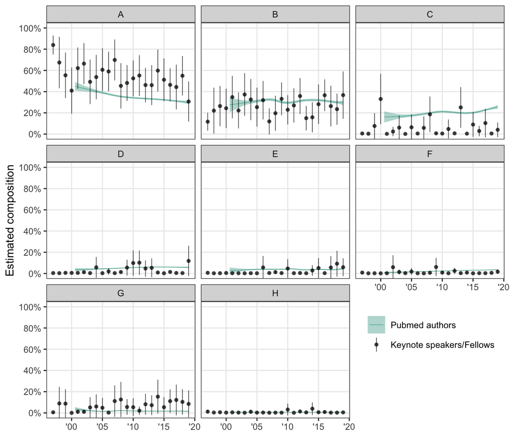

```r
fig_s5 <- iscb_pubmed %>%
  recode_region_letter() %>%
  loess_and_ci() +
  theme(legend.position = c(0.84, 0.2)) +
  facet_wrap(vars(fct_relevel(region, region_levels_let)))
fig_s5
```

```r
ggsave('figs/fig_s5.png', fig_s5, width = 6, height = 6)
```